# RNA-Seq Analysis of Esophageal Squamous Cell Carcinoma (ESCC) and Paired Normal Tissue

Chaeyoung Kim

2024-12-13

This R script identifies differentially expressed genes between esophageal squamous cell carcinoma (ESCC) tissue and paired normal tissue from six individual patients. MultiQC analysis was performed using an HPC environment, and this script processes pre-aligned gene count data published on GEO. The analysis begins with general data exploration, followed by preprocessing, normalization, and statistical analysis using the “edgeR” package.

## General info

- Species: Homo Sapiens
- Sequencing device: Illumina HiSeq 2500
- Single- or paired-end sequencing: Paired-end sequencing
- Samples: This dataset includes six ESCC tumor and six adjacent normal tissue samples obtained from six individuals
- Muli Qc performed with HPC. Trimming and mapping has not been done due to the issue regarding the access into HPC. Instead, statistical analysis performed with raw count data downloaded from NCBI (https://www.ncbi.nlm.nih.gov/geo/query/acc.cgi?acc=GSE194116).

### load required packages

```r
##load required package
library(edgeR)
library(limma)
library(AnnotationDbi)
library(org.Hs.eg.db)
library(GO.db)
library(clusterProfiler)
```

### Setup working directory

```r
setwd("/Users/kimchaeyoung/Desktop/Applied_HT_analysis/Project")
```

### Load dataset

```r
# Read in text file
rnadatafull <- read.table("GSE194116_Raw_gene_counts_matrix.txt", header = T, sep = "\t", quote = "")

#Have a look at the data
head(rnadatafull)
```

```
##        ensembl_id gene_name Normal.1.count Normal.2.count Normal.3.count
## 1 ENSG00000000003    TSPAN6           2043           2635           1566
## 2 ENSG00000000005      TNMD              3              8              3
## 3 ENSG00000000419      DPM1            339            320            304
## 4 ENSG00000000457     SCYL3            717            689            567
## 5 ENSG00000000460  C1orf112            206            229            172
## 6 ENSG00000000938       FGR            178            702            636
##   Normal.4.count Normal.5.count Normal.6.count ECA.1.count ECA.2.count
## 1           1150           1396           2053        1321         787
## 2              6              5              3           0           0
## 3            296            410            427         887         528
## 4            747            725            787         422         594
## 5            231            234            331         483         796
## 6            551            230            304         276         144
##   ECA.3.count ECA.4.count ECA.5.count ECA.6.count
## 1         417         999        1202         646
## 2           0           0           1           0
## 3         873         488         530         778
## 4         710         550         530         441
## 5         690         622         625         564
## 6         241         262         254         706
```

```r
# save ensemble IDs and gene names in separate variable
geneIDs <- rnadatafull[,1:2]

head(geneIDs)
```

```
##        ensembl_id gene_name
## 1 ENSG00000000003    TSPAN6
## 2 ENSG00000000005      TNMD
## 3 ENSG00000000419      DPM1
## 4 ENSG00000000457     SCYL3
## 5 ENSG00000000460  C1orf112
## 6 ENSG00000000938       FGR
```

## 1. Preprocess data

```r
## Separate numerical data (count data) from annotation
rownames(rnadatafull) <- 1:nrow(rnadatafull)
rnadata <- rnadatafull[, 3:14]

## Make annotation for design later on
individuals <- factor(c("patient1", "patient2", "patient3", "patient4", "patient5", "patient6","patient1", "patient2", "patient3", "patient4", "patient5", "patient6"))

cvst <- factor(c("Normal", "Normal", "Normal", "Normal", "Normal", "Normal","ESCC","ESCC","ESCC","ESCC","ESCC","ESCC"))
```

### 1.1. Further preprocessing

```r
# Create DGEList object: 'rnadata' contains the count data, and 'rnadatafull[, 1:2]' contains gene information
y <- DGEList(rnadata, genes = rnadatafull[, 1:2])

# Optional filter
# 'lib.size' refers to the library size of each sample. We calculate CPM (Counts Per Million) values,and apply a filtering threshold (cutoff) to remove genes with low counts.
cutoff <- 3 / (mean(y$samples$lib.size) / 1000000)

#Keep genes with CPM greater than the cutoff in at least 6 samples:
keep <- rowSums(cpm(y) > cutoff) >= 6
#This provides information on how many genes passed the filtering criteria
summary(keep)
```

```
##    Mode   FALSE    TRUE
## logical   15849   24315
```

```r
# Update DGEList object to include only the filtered genes
y <- y[keep, , keep.lib.sizes = FALSE]
```

### 1.2. Normalization

```r
y <- calcNormFactors(y)

# Have a look at the library sizes and normalization factors
y$samples
```

```
##                group lib.size norm.factors
## Normal.1.count     1 22294014    0.9438172
## Normal.2.count     1 21970627    0.9856696
## Normal.3.count     1 21787999    0.9169301
## Normal.4.count     1 19353923    1.0573374
## Normal.5.count     1 20592391    1.0111336
## Normal.6.count     1 18508014    1.0568192
## ECA.1.count        1 20507630    1.0195277
## ECA.2.count        1 17650965    1.0776411
## ECA.3.count        1 17247682    1.0271229
## ECA.4.count        1 19620147    0.9853978
## ECA.5.count        1 22725078    0.9369623
## ECA.6.count        1 19252943    0.9958464
```

### 1.3. MDS plot

- Visualize Sample Similarity -The MDS plot clearly distinguishes between the Normal and ECA groups, effectively highlighting significant biological differences between the two conditions. The variability within the ECA group suggests heterogeneity, offering potential insights through further analysis.

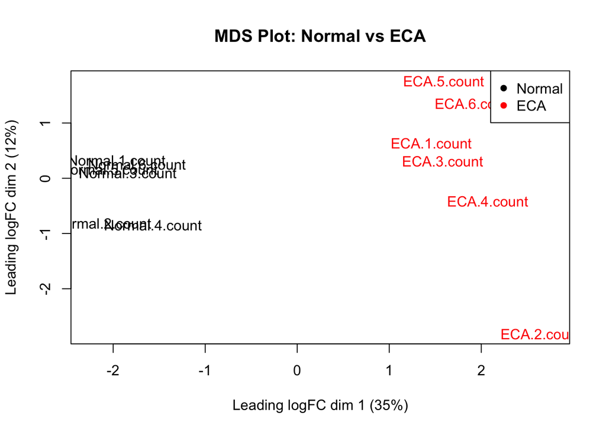

```r
# Define colors for Normal (black) and ECA (red)
colors <- ifelse(grepl("^Normal", rownames(y$samples)), "black", "red")

# Plot MDS with specified colors
plotMDS(y, col=colors, main = "MDS Plot: Normal vs ECA")

# Add legend
legend("topright", legend=c("Normal", "ECA"), col=c("black", "red"), pch=16)
```

## 2. EdgeR differential expression analysis - Paired analysis

- as my dataset has been obtained from paired design experiment, perform paired analysis

### 2.1. Create design matrix

In paired data analysis, I need to account for within-individual variation to correctly identify the effects of the variable of interest (cvst in this case). The design matrix (model.matrix) is created to include both the condition (cvst) and the individual effect (individuals) as factors. This ensures that any differences detected between conditions are not confounded by differences inherent to the individuals.

```r
# Create a design matrix: The 'cvst' variable represents the condition (e.g., Normal vs ECA), and 'individuals' represents the paired samples (e.g., patient1, patient2, etc.).

# The design matrix specifies how the data is modeled in terms of the experimental design.
design <- model.matrix(~ cvst + individuals)
design
```

```
##    (Intercept) cvstNormal individualspatient2 individualspatient3
## 1            1          1                   0                   0
## 2            1          1                   1                   0
## 3            1          1                   0                   1
## 4            1          1                   0                   0
## 5            1          1                   0                   0
## 6            1          1                   0                   0
## 7            1          0                   0                   0
## 8            1          0                   1                   0
## 9            1          0                   0                   1
## 10           1          0                   0                   0
## 11           1          0                   0                   0
## 12           1          0                   0                   0
##    individualspatient4 individualspatient5 individualspatient6
## 1                    0                   0                   0
```

[output cut: 19 more lines]

```r
rownames(design) <- colnames(y)
y <- estimateDisp(y, design)
```

### 2.2 Plot BCV (biological coefficient of variation) plot

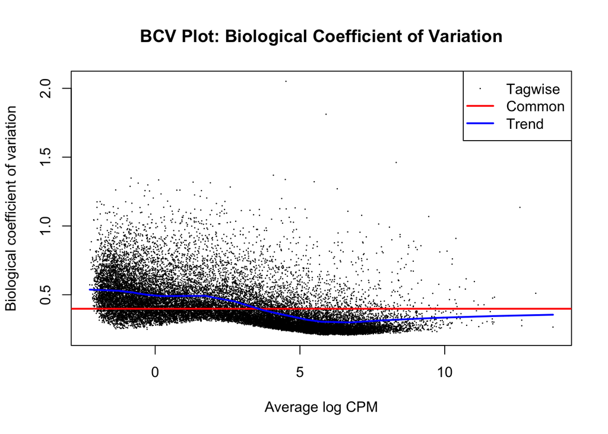

```r
plotBCV(y, main = "BCV Plot: Biological Coefficient of Variation")
```

### 2.3. Fitting model and making a qq-plot to evaluate goodness of fit.

-The central points follow the theoretical distribution well, indicating the model fits most of the data appropriately. However, deviations at the tails suggest the model may not handle extreme values effectively.

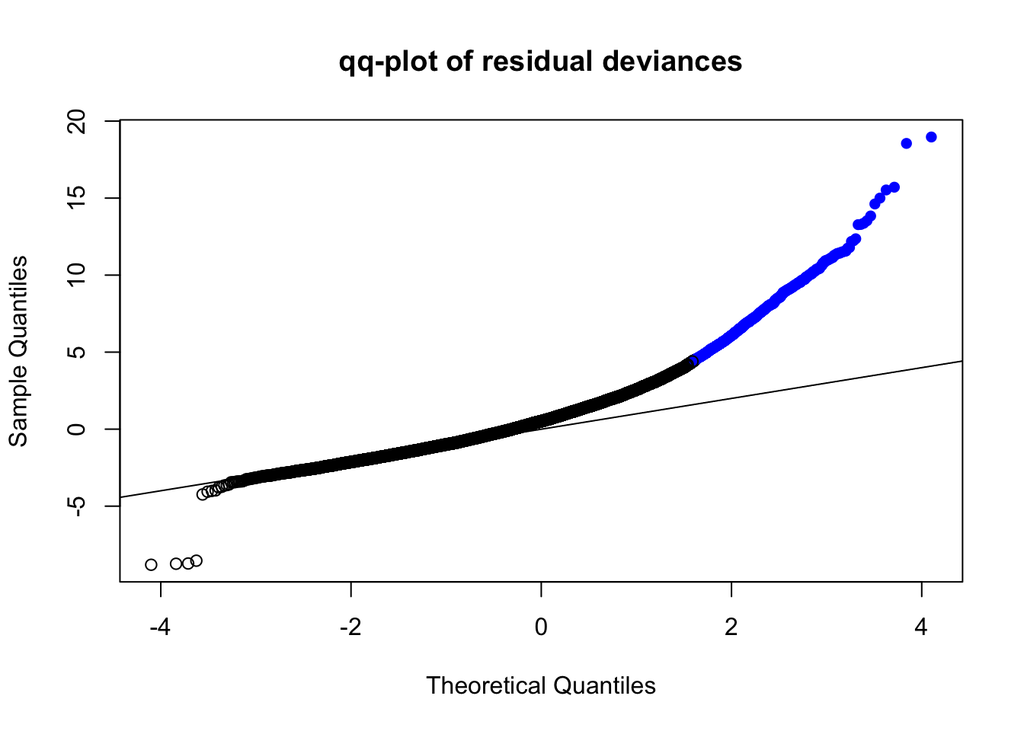

```r
# glmQLFit, glmLRT 수행
fit <- glmQLFit(y, design)
gof(fit,plot=TRUE)
```

### 2.4. glmQSFTest

- Evaluate the significance of coefficients (in this case, the second coefficient).The argument `coef = 2` specifies that the second coefficient in the model. The null hypothesis tested here is that there is no difference in expression between the groups being compared (e.g., Normal vs. ESCC).

```r
# glmQLFTest() performs a Likelihood Ratio Test (LRT) based on the fitted model
qlf <- glmQLFTest(fit, coef = 2)
summary(qlf)
```

```
##                       Length Class            Mode
## coefficients          170205 -none-           numeric
## fitted.values         291780 -none-           numeric
## deviance               24315 -none-           numeric
## iter                   24315 -none-           numeric
## failed                 24315 -none-           logical
## method                     1 -none-           character
## unshrunk.coefficients 170205 -none-           numeric
## df.residual            24315 -none-           numeric
## design                    84 -none-           numeric
## offset                291780 CompressedMatrix numeric
## dispersion                 1 -none-           numeric
## prior.count                1 -none-           numeric
## leverage              291780 -none-           numeric
## unit.deviance.adj     291780 -none-           numeric
## unit.df.adj           291780 -none-           numeric
## df.residual.adj        24315 -none-           numeric
## deviance.adj           24315 -none-           numeric
## average.ql.dispersion      1 -none-           numeric
## df.prior                   1 -none-           numeric
## var.post               24315 -none-           numeric
## var.prior              24315 -none-           numeric
## samples                    3 data.frame       list
## genes                      2 data.frame       list
## AveLogCPM              24315 -none-           numeric
## table                      4 data.frame       list
## comparison                 1 -none-           character
## df.test                24315 -none-           numeric
## df.total               24315 -none-           numeric
```

```r
resP <- topTags(qlf, n = nrow(qlf$table))
# Save the full result of the differential expression analysis to a text file
write.table(resP$table , file = "resP_edgeR_ESCC.txt", col.names = T, row.names = F, sep = "\t", quote = F)

rownames(resP$table) <- y$genes$ensembl_id
# Filter the result to only include genes with a p-value less than 0.05 (statistically significant genes)
resP_edgeR <- resP$table[resP$table[, ncol(resP$table)] < 0.05, ]

# Display the number of rows (genes) in the filtered result
num_rows <- nrow(resP_edgeR)
cat("Number of rows in resP_edgeR:", num_rows, "\n")
```

```
## Number of rows in resP_edgeR: 7305
```

```r
dim(resP_edgeR)
```

```
## [1] 7305    7
```

```r
down_regulated <- sum(resP_edgeR$logFC < 0)
down_regulated
```

```
## [1] 3525
```

```r
up_regulated <- sum(resP_edgeR$logFC > 0)
up_regulated
```

```
## [1] 3780
```

### 2.5. Create Volvano plot

- visualize the results of differential expression analysis
- Genes on the left and right are downregulated and upregulated, respectively. Black points represent genes with no significant change.

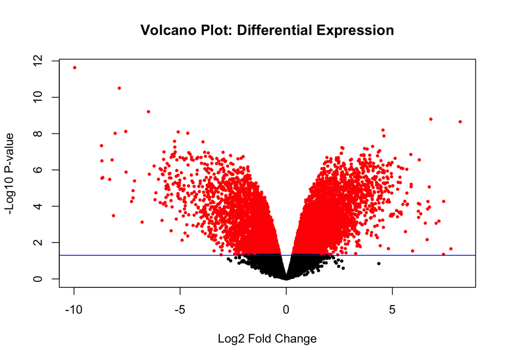

```r
# -log10 transform of Pvalue
resP$table$negLogP <- -log10(resP$table$PValue)

with(resP$table, plot(logFC, negLogP,
                      pch = 16, cex = 0.6,
                      col = ifelse(PValue < 0.05, "red", "black"),
                      main = "Volcano Plot: Differential Expression",
                      xlab = "Log2 Fold Change",
                      ylab = "-Log10 P-value"))

abline(h = -log10(0.05), col = "blue")
```

### 2.6. Creating MA plot

-Visualize the relationship between the mean expression level (average expression) and the log fold change (difference in expression) for each gene between two conditions. -The red points, which are spread out, indicate genes with significant differences in expression between the tumor and normal tissue samples. These are the genes that are most likely biologically relevant for further investigation.

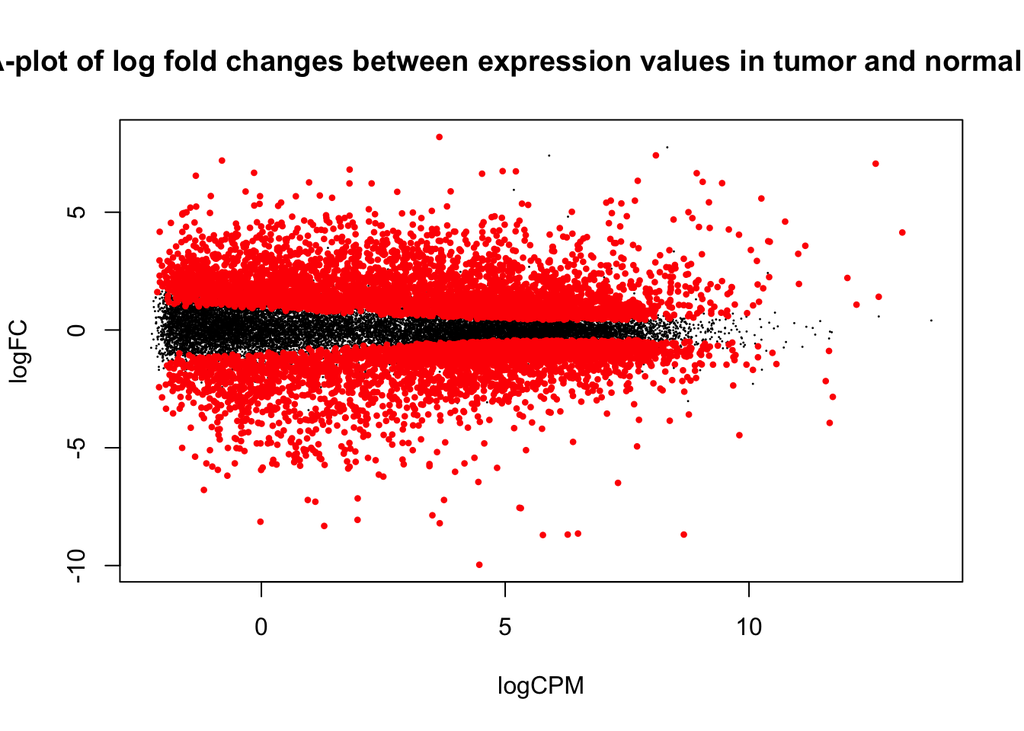

```r
with(resP$table , plot(logCPM , logFC , pch = 16, cex = 0.2, main = "MA-plot of log fold changes between expression values in tumor and normal tissue."))
with(resP$table, points(logCPM[FDR < 0.05], logFC[FDR < 0.05], pch =
                          16, col = "red", cex = 0.6))
```

### 2.7 Plot histogram of P-values

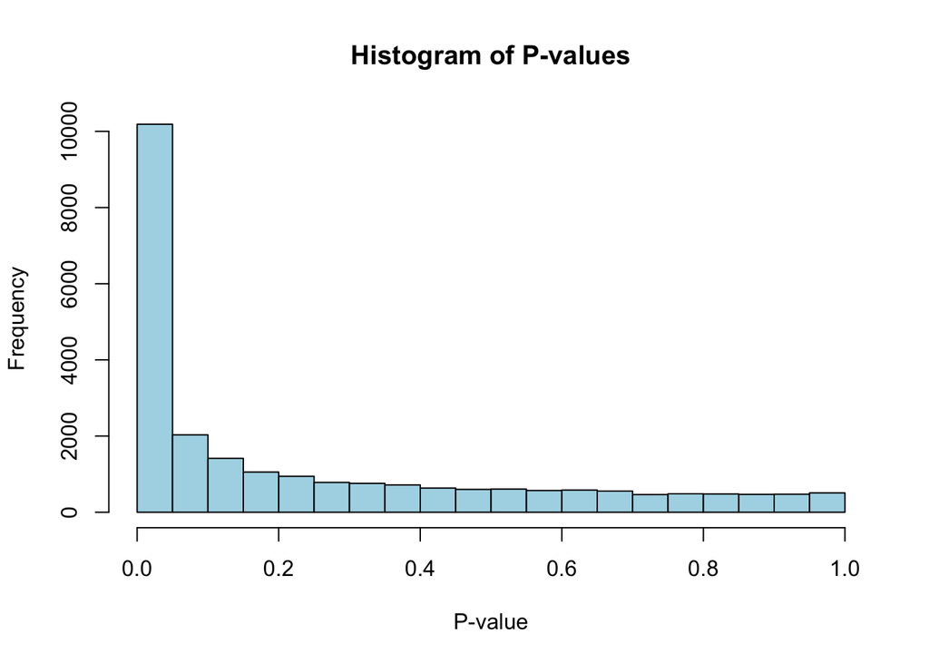

```r
hist(resP$table$PValue, main = "Histogram of P-values", xlab = "P-value", col = "lightblue")
```

### 2.8. Top10 differentially expressed genes

- Display the most significant differential expression results (top10) between normal and ESCC tissue in the RNA-seq analysis.

```r
head(resP$table[, c(1, 2, 3, 6, 7)], 10)
```

```
##                      ensembl_id gene_name     logFC       PValue          FDR
## ENSG00000000003 ENSG00000170373      CST1 -9.966594 2.335211e-12 5.678066e-08
## ENSG00000000419 ENSG00000170454     KRT75 -7.865582 3.137313e-11 3.814188e-07
## ENSG00000000457 ENSG00000099953     MMP11 -6.491084 6.212125e-10 5.034927e-06
## ENSG00000000460 ENSG00000187848     P2RX2  6.810847 1.607231e-09 9.769953e-06
## ENSG00000000938 ENSG00000181092    ADIPOQ  8.193276 2.219090e-09 1.079144e-05
## ENSG00000000971 ENSG00000137766    UNC13C  4.555104 6.374277e-09 2.351332e-05
## ENSG00000001036 ENSG00000123500   COL10A1 -7.563470 7.600829e-09 2.351332e-05
## ENSG00000001084 ENSG00000173157  ADAMTS20 -5.091863 8.057611e-09 2.351332e-05
## ENSG00000001167 ENSG00000099812      MISP -4.641954 9.502751e-09 2.351332e-05
## ENSG00000001460 ENSG00000127928     GNGT1 -8.060504 9.670295e-09 2.351332e-05
```

## 3. Gene Set Analysis

```r
# Display the first 10 rows of resP_edgeR
head(resP_edgeR, 10)
```

```
##                      ensembl_id gene_name     logFC   logCPM        F
## ENSG00000000003 ENSG00000170373      CST1 -9.966594 4.469789 492.1460
## ENSG00000000419 ENSG00000170454     KRT75 -7.865582 3.506998 299.4413
## ENSG00000000457 ENSG00000099953     MMP11 -6.491084 7.313593 560.6491
## ENSG00000000460 ENSG00000187848     P2RX2  6.810847 1.809978 177.2143
## ENSG00000000938 ENSG00000181092    ADIPOQ  8.193276 3.649818 266.4165
## ENSG00000000971 ENSG00000137766    UNC13C  4.555104 1.393889 211.5872
## ENSG00000001036 ENSG00000123500   COL10A1 -7.563470 5.320874 337.5784
## ENSG00000001084 ENSG00000173157  ADAMTS20 -5.091863 1.056572 169.7713
## ENSG00000001167 ENSG00000099812      MISP -4.641954 2.615540 276.4453
## ENSG00000001460 ENSG00000127928     GNGT1 -8.060504 1.972294 201.4226
##                       PValue          FDR
## ENSG00000000003 2.335211e-12 5.678066e-08
## ENSG00000000419 3.137313e-11 3.814188e-07
## ENSG00000000457 6.212125e-10 5.034927e-06
## ENSG00000000460 1.607231e-09 9.769953e-06
## ENSG00000000938 2.219090e-09 1.079144e-05
## ENSG00000000971 6.374277e-09 2.351332e-05
## ENSG00000001036 7.600829e-09 2.351332e-05
## ENSG00000001084 8.057611e-09 2.351332e-05
## ENSG00000001167 9.502751e-09 2.351332e-05
## ENSG00000001460 9.670295e-09 2.351332e-05
```

```r
EntrezIDs <- mapIds(org.Hs.eg.db, rownames(resP_edgeR), 'ENTREZID', 'ENSEMBL')
sign_genes_entrez <- resP_edgeR[!(duplicated(EntrezIDs) | is.na(EntrezIDs)), ]
rownames(sign_genes_entrez) <- EntrezIDs[!(duplicated(EntrezIDs) | is.na(EntrezIDs))]

goanaOut <- goana(de=rownames(sign_genes_entrez), species="Hs", trend=T)
goanaOut <- goanaOut[order(goanaOut$P.DE, decreasing=FALSE),]
goanaOut$FDR.DE <- p.adjust(goanaOut$P.DE, method="BH")
topGORNA <- topGO(goanaOut, ontology="BP", number=50)

goanaOut_BP <- goanaOut[goanaOut$Ont == "BP",]
print(paste("Amount of significant GO Biological Process terms:",
as.character(sum(goanaOut_BP$FDR.DE < 0.05))))
```

```
## [1] "Amount of significant GO Biological Process terms: 2066"
```

```r
topGORNA[order(topGORNA$N),]
```

```
##                                                                  Term Ont     N
## GO:0046907                                    intracellular transport  BP  1357
## GO:0015031                                          protein transport  BP  1415
## GO:0045184                      establishment of protein localization  BP  1701
## GO:0033554                                cellular response to stress  BP  1847
## GO:0071705                                nitrogen compound transport  BP  1903
## GO:0051649                      establishment of localization in cell  BP  1947
## GO:0071702                                organic substance transport  BP  2370
## GO:0051128              regulation of cellular component organization  BP  2459
## GO:0008104                                       protein localization  BP  2505
## GO:0070727                        cellular macromolecule localization  BP  2516
## GO:0006796            phosphate-containing compound metabolic process  BP  2559
## GO:0006793                               phosphorus metabolic process  BP  2585
## GO:0009056                                          catabolic process  BP  2668
## GO:0035556                          intracellular signal transduction  BP  2721
## GO:0036211                               protein modification process  BP  2958
## GO:0033036                                 macromolecule localization  BP  3004
## GO:0051173 positive regulation of nitrogen compound metabolic process  BP  3083
## GO:0043412                                 macromolecule modification  BP  3191
## GO:0044085                              cellular component biogenesis  BP  3368
## GO:0051641                                      cellular localization  BP  3384
## GO:0031325          positive regulation of cellular metabolic process  BP  3440
## GO:0010604     positive regulation of macromolecule metabolic process  BP  3506
## GO:0023051                                    regulation of signaling  BP  3554
## GO:0010646                           regulation of cell communication  BP  3559
## GO:0006996                                     organelle organization  BP  3623
## GO:0009893                   positive regulation of metabolic process  BP  3816
## GO:0006950                                         response to stress  BP  3984
## GO:0048731                                         system development  BP  4072
## GO:0048583                         regulation of response to stimulus  BP  4116
## GO:0006810                                                  transport  BP  4385
## GO:0051234                              establishment of localization  BP  4698
## GO:0007275                         multicellular organism development  BP  4764
## GO:0019538                                  protein metabolic process  BP  4915
## GO:0051179                                               localization  BP  5335
## GO:0048522                    positive regulation of cellular process  BP  5861
## GO:1901564                  organonitrogen compound metabolic process  BP  5992
## GO:0048856                           anatomical structure development  BP  6016
## GO:0048518                  positive regulation of biological process  BP  6411
## GO:0016043                            cellular component organization  BP  6581
```

[output cut: 47 more lines]

```
## GO:1901564 2699  8.710776e-86 1.403742e-82
## GO:0048856 2587  2.623950e-56 1.345430e-53
## GO:0048518 2801  7.704438e-72 7.900901e-69
## GO:0016043 2953  6.361506e-95 1.104015e-91
## GO:0032502 2813  3.844905e-59 2.344457e-56
## GO:0071840 3055 1.260280e-101 2.369432e-98
## GO:0051716 3129  8.980741e-48 3.434144e-45
## GO:0050896 3659  4.849122e-40 1.334159e-37
## GO:0006807 4095  3.608089e-60 2.394179e-57
## GO:0044238 4270  1.375643e-61 1.001157e-58
## GO:0071704 4573  6.011754e-43 1.832854e-40
## GO:0008152 4775  1.747721e-47 6.463990e-45
## GO:0065007 4846  1.565525e-38 3.924422e-36
## GO:0009987 6561  1.545568e-72 1.660456e-69
## GO:0008150 6892  3.116839e-68 3.057348e-65
```

```r
#### Gene Set Analysis
# GO analysis (Biological Process)

go_results <- enrichGO(gene = rownames(sign_genes_entrez),
                       OrgDb = org.Hs.eg.db,
                       ont = "BP",       # GO Biological Process (BP)
                       pAdjustMethod = "BH",
                       pvalueCutoff = 0.05,
                       qvalueCutoff = 0.05)

go_results_df <- as.data.frame(go_results)
```

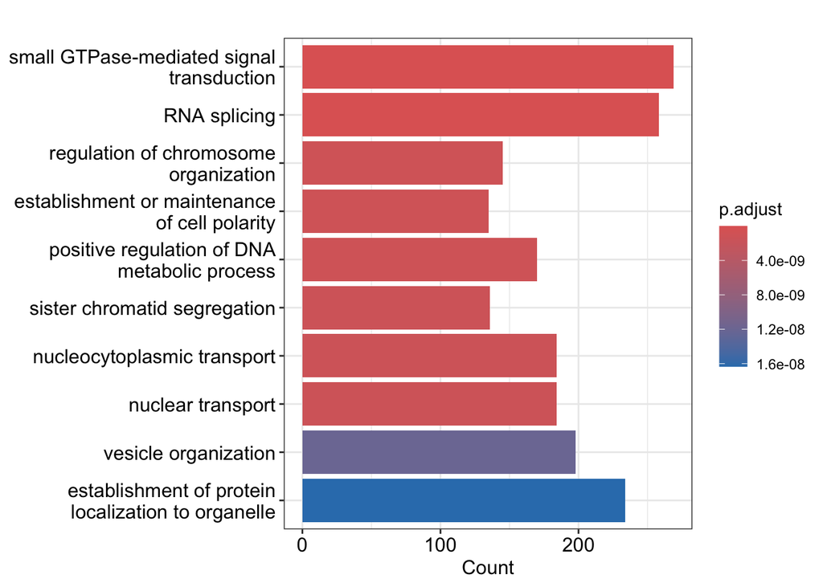

```r
#visualize only top10 Go results
barplot(go_results, showCategory = 10)
```

```r
RNAseq_GSA_res <- topGO(goanaOut, ontology="BP", number=100)

# write GSA results into text file for further analysis
write.table(RNAseq_GSA_res, sep= "\t", file="RNAseq_GSA_results.txt")
```

## 4. save the results for futher analysis

```r
edgeR_res <- resP_edgeR[order(resP_edgeR$FDR, decreasing=F),]
write.table(edgeR_res, sep= "\t", file="RNAseq_results.txt")

RNAseq_GSA_res <- topGO(goanaOut, ontology="BP", number=100)
write.table(RNAseq_GSA_res, sep= "\t", file="RNAseq_GSA_results.txt")
```